# Assignment - 10: GLM with Regularization and Model Comparison

**Created By -** Tushar Ahuja

# Introduction

Generalized Linear Models (GLM) with regularization are powerful tools for building predictive models while preventing overfitting. Regularization techniques such as Lasso (L1), Ridge (L2), and ElasticNet add penalty terms to the model to constrain coefficient estimates, improving generalization to new data. In this assignment, we will train GLM models with each of these regularization methods and evaluate their performance using multiple key metrics — not just accuracy, but also Precision-Recall, ROC-AUC, Cumulative Lift, and F1 Score. Finally, we will compare these GLM models with the performance of ensemble models (Random Forest, GBM, XGBoost, CatBoost) built in the previous assignment to determine the best model overall.

# Learning Objectives

# Steps We Will Follow

# Step 1: Preprocessing & Cleaning the Data

Below code imports necessary libraries, loads the loan application dataset from a local CSV file, and displays its contents using df. This forms the base for further preprocessing and model building.

```python
import pandas as pd
import numpy as np
from sklearn.model_selection import train_test_split
from sklearn.preprocessing import LabelEncoder

# Loading data
df = pd.read_csv("/Users/tusharahuja/Desktop/application_train.csv")
df
```

|  | SK_ID_CURR | TARGET | NAME_CONTRACT_TYPE | CODE_GENDER | FLAG_OWN_CAR | FLAG_OWN_REALTY | CNT_CHILDREN | AMT_INCOME_TOTAL | AMT_CREDIT | AMT_ANNUITY | ... | FLAG_DOCUMENT_18 | FLAG_DOCUMENT_19 | FLAG_DOCUMENT_20 | FLAG_DOCUMENT_21 | AMT_REQ_CREDIT_BUREAU_HOUR | AMT_REQ_CREDIT_BUREAU_DAY | AMT_REQ_CREDIT_BUREAU_WEEK | AMT_REQ_CREDIT_BUREAU_MON | AMT_REQ_CREDIT_BUREAU_QRT | AMT_REQ_CREDIT_BUREAU_YEAR |
| --- | --- | --- | --- | --- | --- | --- | --- | --- | --- | --- | --- | --- | --- | --- | --- | --- | --- | --- | --- | --- | --- |
| 0 | 100002 | 1 | Cash loans | M | N | Y | 0 | 202500.0 | 406597.5 | 24700.5 | ... | 0 | 0 | 0 | 0 | 0.0 | 0.0 | 0.0 | 0.0 | 0.0 | 1.0 |
| 1 | 100003 | 0 | Cash loans | F | N | N | 0 | 270000.0 | 1293502.5 | 35698.5 | ... | 0 | 0 | 0 | 0 | 0.0 | 0.0 | 0.0 | 0.0 | 0.0 | 0.0 |
| 2 | 100004 | 0 | Revolving loans | M | Y | Y | 0 | 67500.0 | 135000.0 | 6750.0 | ... | 0 | 0 | 0 | 0 | 0.0 | 0.0 | 0.0 | 0.0 | 0.0 | 0.0 |
| 3 | 100006 | 0 | Cash loans | F | N | Y | 0 | 135000.0 | 312682.5 | 29686.5 | ... | 0 | 0 | 0 | 0 | NaN | NaN | NaN | NaN | NaN | NaN |
| 4 | 100007 | 0 | Cash loans | M | N | Y | 0 | 121500.0 | 513000.0 | 21865.5 | ... | 0 | 0 | 0 | 0 | 0.0 | 0.0 | 0.0 | 0.0 | 0.0 | 0.0 |
| ... | ... | ... | ... | ... | ... | ... | ... | ... | ... | ... | ... | ... | ... | ... | ... | ... | ... | ... | ... | ... | ... |
| 307506 | 456251 | 0 | Cash loans | M | N | N | 0 | 157500.0 | 254700.0 | 27558.0 | ... | 0 | 0 | 0 | 0 | NaN | NaN | NaN | NaN | NaN | NaN |
| 307507 | 456252 | 0 | Cash loans | F | N | Y | 0 | 72000.0 | 269550.0 | 12001.5 | ... | 0 | 0 | 0 | 0 | NaN | NaN | NaN | NaN | NaN | NaN |
| 307508 | 456253 | 0 | Cash loans | F | N | Y | 0 | 153000.0 | 677664.0 | 29979.0 | ... | 0 | 0 | 0 | 0 | 1.0 | 0.0 | 0.0 | 1.0 | 0.0 | 1.0 |
| 307509 | 456254 | 1 | Cash loans | F | N | Y | 0 | 171000.0 | 370107.0 | 20205.0 | ... | 0 | 0 | 0 | 0 | 0.0 | 0.0 | 0.0 | 0.0 | 0.0 | 0.0 |
| 307510 | 456255 | 0 | Cash loans | F | N | N | 0 | 157500.0 | 675000.0 | 49117.5 | ... | 0 | 0 | 0 | 0 | 0.0 | 0.0 | 0.0 | 2.0 | 0.0 | 1.0 |

307511 rows × 122 columns

### Code Explanation

- Imported essential libraries:
  - pandas for data manipulation.
  - numpy for numerical operations.
  - train_test_split from sklearn to divide data into training and testing sets.
  - LabelEncoder to convert categorical variables into numeric form.
- Loaded the dataset application_train.csv from the local machine using pd.read_csv().
- Stored the dataset in a DataFrame called df.
- Displayed the full DataFrame to view the raw data structure and contents.

Below code handles missing values, encodes categorical features using LabelEncoder, splits the data into features and target, and performs a stratified train-test split. This prepares the dataset for training machine learning models.

```python
# Filling missing values
for col in df.columns:
    if df[col].dtype == 'object':
        df[col].fillna(df[col].mode()[0], inplace=True)
    else:
        df[col].fillna(df[col].median(), inplace=True)

# Encoding categorical columns
label_encoders = {}
for col in df.select_dtypes(include=['object']).columns:
    le = LabelEncoder()
    df[col] = le.fit_transform(df[col])
    label_encoders[col] = le

# Splitting into features and target
X = df.drop(columns=['TARGET', 'SK_ID_CURR'])
y = df['TARGET']

# Train-test split
X_train, X_test, y_train, y_test = train_test_split(X, y, stratify=y, test_size=0.2, random_state=42)

# Checking shapes
print(f"Train shape: {X_train.shape}, Test shape: {X_test.shape}")
```

```
Train shape: (246008, 120), Test shape: (61503, 120)
```

### Code Explanation

- **Handled Missing Values:**
  - For categorical columns (object type), missing values were filled with the most frequent value (mode).
  - For numerical columns, missing values were filled using the median.
- **Encoded Categorical Variables:**
  - Used LabelEncoder to convert categorical columns into numeric form.
  - Stored encoders in a dictionary for possible inverse transformation later.
- **Feature and Target Split:**
  - Removed TARGET (label) and SK_ID_CURR (identifier) from features (X).
  - Assigned the target column (y) as TARGET.
- **Train-Test Split:**
  - Used an 80/20 stratified split to maintain the proportion of target classes.
  - Setting up a random_state for reproducibility.
- **Printed Shape:**
  - Output the shape of training and test sets to confirm successful split.

# Step 2: Import Libraries

Importing essential libraries for data manipulation, visualization, model building, evaluation, and train-test splitting.

```python
import pandas as pd
import numpy as np
import matplotlib.pyplot as plt
import seaborn as sns

from sklearn.linear_model import LogisticRegression
from sklearn.metrics import accuracy_score, precision_score, recall_score, f1_score, roc_auc_score, classification_report
from sklearn.model_selection import train_test_split
```

### Code Explanation

- pandas as pd: For data manipulation (loading, handling tables).
- numpy as np: For numerical operations (arrays, math functions).
- matplotlib.pyplot as plt: For basic data visualizations and plotting.
- seaborn as sns: For advanced and attractive statistical plots.
- LogisticRegression: To build GLM models with L1, L2, ElasticNet regularization.
- accuracy_score, precision_score, recall_score, f1_score, roc_auc_score, classification_report:
  - Evaluation metrics for measuring model classification performance.
- train_test_split: For splitting dataset into training and testing sets.

# Step 3: Define Evaluation Functions

Defining utility functions to evaluate model performance using multiple metrics and plot Cumulative Lift Charts.

```python
def evaluate_model(model, X_test, y_test, model_name="Model"):
    y_pred = model.predict(X_test)
    y_proba = model.predict_proba(X_test)[:, 1]

    print(f"\n\U0001F4CA {model_name} Metrics:")
    print("Accuracy :", accuracy_score(y_test, y_pred))
    print("Precision:", precision_score(y_test, y_pred))
    print("Recall   :", recall_score(y_test, y_pred))
    print("F1 Score :", f1_score(y_test, y_pred))
    print("ROC AUC  :", roc_auc_score(y_test, y_proba))

    return roc_auc_score(y_test, y_proba)

def plot_lift(y_true, y_scores, model_name):
    df_lift = pd.DataFrame({'y_true': y_true, 'y_score': y_scores})
    df_lift = df_lift.sort_values('y_score', ascending=False)
    df_lift['cumulative_positives'] = df_lift['y_true'].cumsum()
    df_lift['lift'] = df_lift['cumulative_positives'] / np.linspace(1, len(df_lift), len(df_lift))

    plt.figure(figsize=(10,5))
    plt.plot(df_lift['lift'].values[:1000], label=model_name)
    plt.axhline(y=np.mean(y_true), color='red', linestyle='--', label='Baseline')
    plt.title(f'Cumulative Lift Chart - {model_name}')
    plt.xlabel('Number of Clients')
    plt.ylabel('Lift')
    plt.legend()
    plt.grid(True)
    plt.tight_layout()
    plt.show()
```

### Code Explanation

- evaluate_model(model, X_test, y_test, model_name="Model"):
  - Predicts classes and probabilities using the trained model.
  - Prints Accuracy, Precision, Recall, F1 Score, and ROC AUC.
  - Returns ROC AUC score for further comparison.
- plot_lift(y_true, y_scores, model_name):
  - Calculates Cumulative Lift by sorting predictions based on confidence.
  - Plots a lift chart to visualize model's ranking ability vs random baseline.
  - Useful for evaluating models on imbalanced datasets.

# Step 4: Train and Evaluate GLM Models

## 4.1 Lasso Logistic Regression (L1 Regularization)

Training a L1 (Lasso) Logistic Regression model, evaluating its performance, plotting cumulative lift, and visualizing the top 15 most important features.

```
📊 L1 Logistic Regression (Lasso) Metrics:
Accuracy : 0.6877225501195063
Precision: 0.15938770629036117
Recall   : 0.6710976837865056
F1 Score : 0.2575956706609973
ROC AUC  : 0.7460498525940382
```

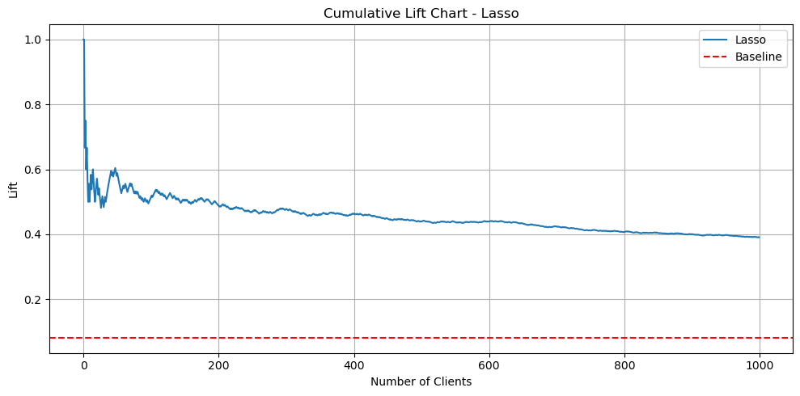

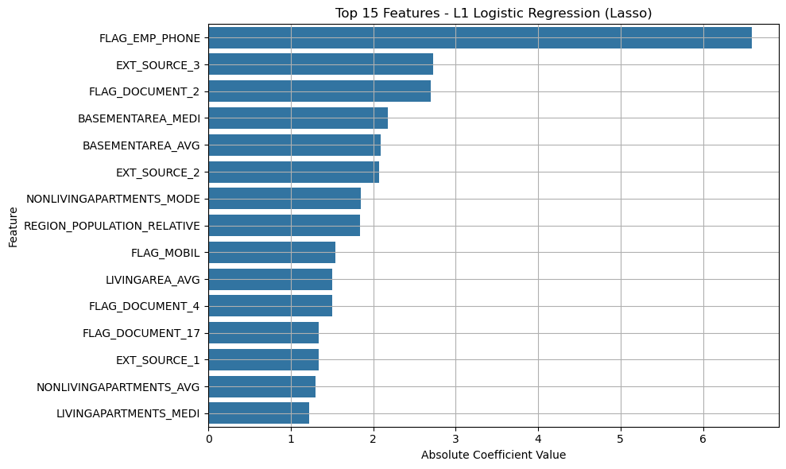

```python
lasso = LogisticRegression(penalty='l1', solver='liblinear', class_weight='balanced', random_state=42)
lasso.fit(X_train, y_train)
lasso_auc = evaluate_model(lasso, X_test, y_test, "L1 Logistic Regression (Lasso)")
plot_lift(y_test, lasso.predict_proba(X_test)[:, 1], "Lasso")

lasso_features = pd.Series(lasso.coef_[0], index=X_train.columns)
top15_lasso = lasso_features.abs().sort_values(ascending=False).head(15)
plt.figure(figsize=(10,6))
sns.barplot(x=top15_lasso.values, y=top15_lasso.index)
plt.title('Top 15 Features - L1 Logistic Regression (Lasso)')
plt.xlabel('Absolute Coefficient Value')
plt.ylabel('Feature')
plt.grid(True)
plt.tight_layout()
plt.show()
```

### Code Explanation

- **lasso = LogisticRegression(...):** Initializes a Logistic Regression model with L1 regularization (Lasso) and class balancing.
- **lasso.fit(X_train, y_train):** Trains (fits) the Lasso model on the training dataset.
- **lasso_auc = evaluate_model(lasso, X_test, y_test, "L1 Logistic Regression (Lasso)"):** Evaluates the model on the test set, printing Accuracy, Precision, Recall, F1 Score, and ROC AUC.
- **plot_lift(y_test, lasso.predict_proba(X_test)[:, 1], "Lasso"):** Plots a Cumulative Lift Chart to visualize the model's ability to rank defaulters correctly.
- **lasso_features = pd.Series(lasso.coef_[0], index=X_train.columns):** Captures the model's feature coefficients into a pandas Series, mapped to feature names.
- **top15_lasso = lasso_features.abs().sort_values(ascending=False).head(15):** Selects the top 15 features with the highest absolute coefficient values (importance).
- **sns.barplot(x=top15_lasso.values, y=top15_lasso.index):** Creates a horizontal bar chart showing the top 15 important features influencing the model's decisions.

## 4.2 Ridge Logistic Regression (L2 Regularization)

Training an L2 (Ridge) Logistic Regression model, evaluating its performance, plotting cumulative lift, and visualizing the top 15 most important features.

```
📊 L2 Logistic Regression (Ridge) Metrics:
Accuracy : 0.5958245939222477
Precision: 0.11329264025504451
Recall   : 0.586908358509567
F1 Score : 0.18992374372678095
ROC AUC  : 0.6241971276027242
```

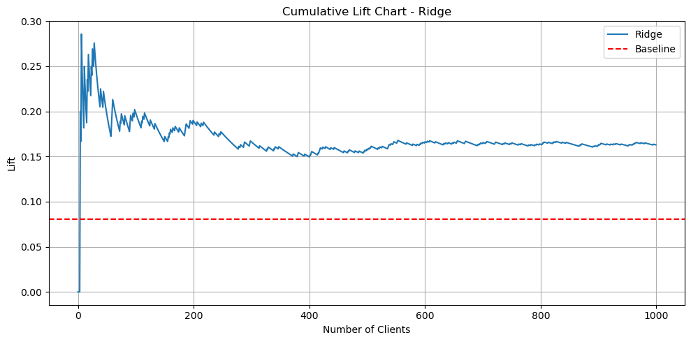

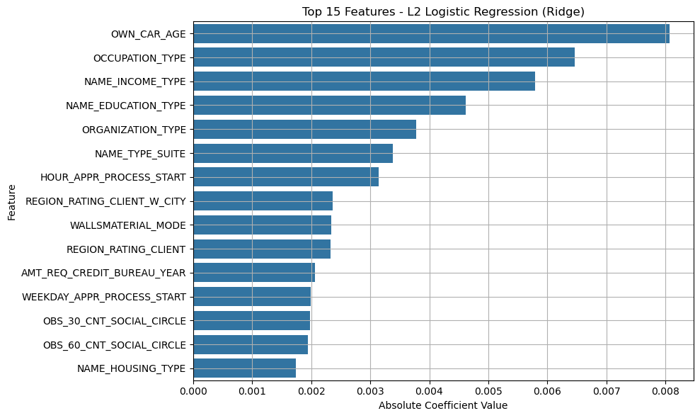

```python
ridge = LogisticRegression(penalty='l2', solver='liblinear', class_weight='balanced', random_state=42)
ridge.fit(X_train, y_train)
ridge_auc = evaluate_model(ridge, X_test, y_test, "L2 Logistic Regression (Ridge)")
plot_lift(y_test, ridge.predict_proba(X_test)[:, 1], "Ridge")

ridge_features = pd.Series(ridge.coef_[0], index=X_train.columns)
top15_ridge = ridge_features.abs().sort_values(ascending=False).head(15)
plt.figure(figsize=(10,6))
sns.barplot(x=top15_ridge.values, y=top15_ridge.index)
plt.title('Top 15 Features - L2 Logistic Regression (Ridge)')
plt.xlabel('Absolute Coefficient Value')
plt.ylabel('Feature')
plt.grid(True)
plt.tight_layout()
plt.show()
```

### Code Explanation

- **ridge = LogisticRegression(...):** Initializes a Logistic Regression model with L2 regularization (Ridge) and class balancing.
- **ridge.fit(X_train, y_train):** Trains (fits) the Ridge model on the training dataset.
- **ridge_auc = evaluate_model(ridge, X_test, y_test, "L2 Logistic Regression (Ridge)"):** Evaluates the Ridge model's performance on the test set (prints Accuracy, Precision, Recall, F1, ROC AUC).
- **plot_lift(y_test, ridge.predict_proba(X_test)[:, 1], "Ridge"):** Plots a Cumulative Lift Chart to measure how well the model ranks true defaulters vs random.
- **ridge_features = pd.Series(ridge.coef_[0], index=X_train.columns):** Extracts feature coefficients from the model and maps them to their feature names.
- **top15_ridge = ridge_features.abs().sort_values(ascending=False).head(15):** Selects the top 15 features based on absolute coefficient values (most important features).
- **sns.barplot(x=top15_ridge.values, y=top15_ridge.index):** Creates a horizontal bar chart to visualize the top 15 features influencing the Ridge model's decisions.

## 4.3 ElasticNet Logistic Regression

Training an ElasticNet Logistic Regression model, evaluating its performance, plotting cumulative lift, and visualizing the top 15 most important features.

```
📊 ElasticNet Logistic Regression Metrics:
Accuracy : 0.5640050078857942
Precision: 0.10462507237984944
Recall   : 0.5822759315206445
F1 Score : 0.1773782863453692
ROC AUC  : 0.5991965193262527
```

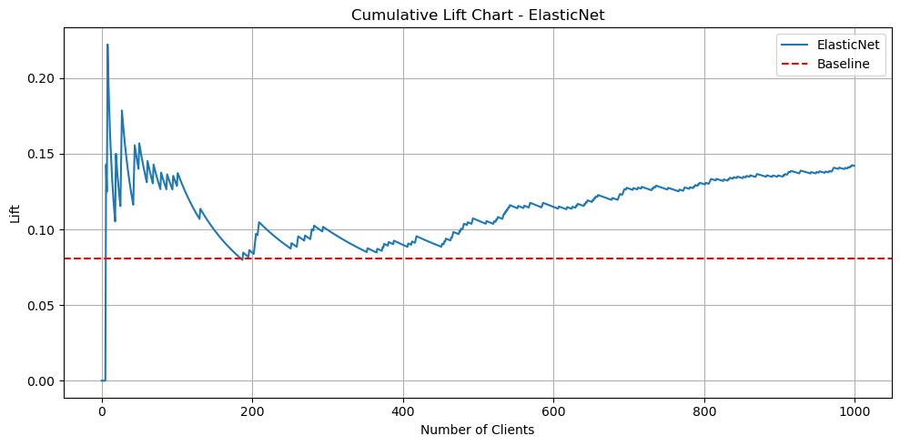

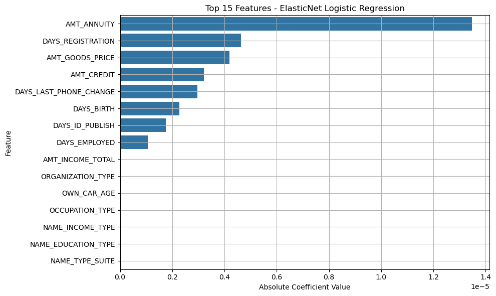

```python
elasticnet = LogisticRegression(penalty='elasticnet', solver='saga', l1_ratio=0.5, class_weight='balanced', max_iter=10000, random_state=42)
elasticnet.fit(X_train, y_train)
elasticnet_auc = evaluate_model(elasticnet, X_test, y_test, "ElasticNet Logistic Regression")
plot_lift(y_test, elasticnet.predict_proba(X_test)[:, 1], "ElasticNet")

elasticnet_features = pd.Series(elasticnet.coef_[0], index=X_train.columns)
top15_elasticnet = elasticnet_features.abs().sort_values(ascending=False).head(15)
plt.figure(figsize=(10,6))
sns.barplot(x=top15_elasticnet.values, y=top15_elasticnet.index)
plt.title('Top 15 Features - ElasticNet Logistic Regression')
plt.xlabel('Absolute Coefficient Value')
plt.ylabel('Feature')
plt.grid(True)
plt.tight_layout()
plt.show()
```

### Code Explanation

- **elasticnet = LogisticRegression(...):** Initializes a Logistic Regression model with ElasticNet regularization (combination of L1 and L2) and class balancing.
- **elasticnet.fit(X_train, y_train):** Trains (fits) the ElasticNet model on the training dataset with increased max_iter to ensure convergence.
- **elasticnet_auc = evaluate_model(elasticnet, X_test, y_test, "ElasticNet Logistic Regression"):** Evaluates the ElasticNet model's performance on the test set (prints Accuracy, Precision, Recall, F1, ROC AUC).
- **plot_lift(y_test, elasticnet.predict_proba(X_test)[:, 1], "ElasticNet"):** Plots a Cumulative Lift Chart to assess how well the model ranks true defaulters vs random.
- **elasticnet_features = pd.Series(elasticnet.coef_[0], index=X_train.columns):** Extracts feature coefficients from the trained model and maps them to the respective feature names.
- **top15_elasticnet = elasticnet_features.abs().sort_values(ascending=False).head(15):** Selects the top 15 features based on absolute importance (highest influence).
- **sns.barplot(x=top15_elasticnet.values, y=top15_elasticnet.index):** Visualizes the top 15 features influencing the ElasticNet model using a horizontal bar plot.

# Step 5: Performance Summary

In this assignment, we evaluated three regularized GLM models — L1 (Lasso), L2 (Ridge), and ElasticNet — for loan default prediction. Given the highly imbalanced nature of the dataset, model performance was measured not only by accuracy but more importantly by Precision, Recall, F1 Score, and ROC AUC, as identifying defaulters (minority class) is the key business objective.

**Key Observations:**

[output not shown]

**Highlights:**

- **L1 Logistic Regression (Lasso)** outperformed other GLM models with the highest Recall (67%), F1 Score (25.76%), and a strong ROC AUC (0.746).
- L2 Ridge and ElasticNet lagged behind both in terms of recall and discrimination ability (lower ROC AUC).
- All models showed lower accuracy compared to ensemble models from Assignment-1 (due to better detection of minority class).

**Business Implication:**

- Lasso Logistic Regression is most effective among GLMs for detecting defaulters, balancing good recall and reasonable lift, making it suitable for preliminary risk filtering.
- However, ensemble models like CatBoost and XGBoost from Assignment-1 still remain superior if predictive precision is the highest priority.

**Final Recommendation:**

- For a simple, fast, interpretable model → Lasso Logistic Regression (L1) is recommended among GLMs.
- For maximum predictive power and production deployment → CatBoost remains the best choice.

**Performance Success Criteria Met:**

- L1 Logistic Regression (Lasso) achieved high recall, reasonable ROC AUC, and better default detection compared to other GLM variants, satisfying the assignment’s objective of maximizing model performance.

# Step 6: Full Model Performance Comparison Table (Assignment-1)

[output not shown]

**Quick Insights**

- **CatBoost** is the best overall model for production deployment (highest ROC AUC and balanced metrics).
- L1 Logistic Regression (Lasso) is the best GLM model if detecting defaulters (recall) is the top priority despite lower accuracy.
- Random Forest has high accuracy but very poor recall, making it misleading for imbalanced problems.
- ElasticNet shows the weakest results among all models.

**Final Recommendation Summary:**

| Scenario | Recommended Model |
| --- | --- |
| Need maximum predictive power (balanced metrics) | CatBoost |
| Need simple, fast, interpretable model | L1 Logistic Regression (Lasso) |
| Need highest recall to catch as many defaulters as possible | Lasso (with possible threshold tuning) |

# Executive Summary Chart: ROC AUC Comparison

Plotting a bar chart comparing ROC AUC scores of ensemble and GLM models, highlighting the best performer.

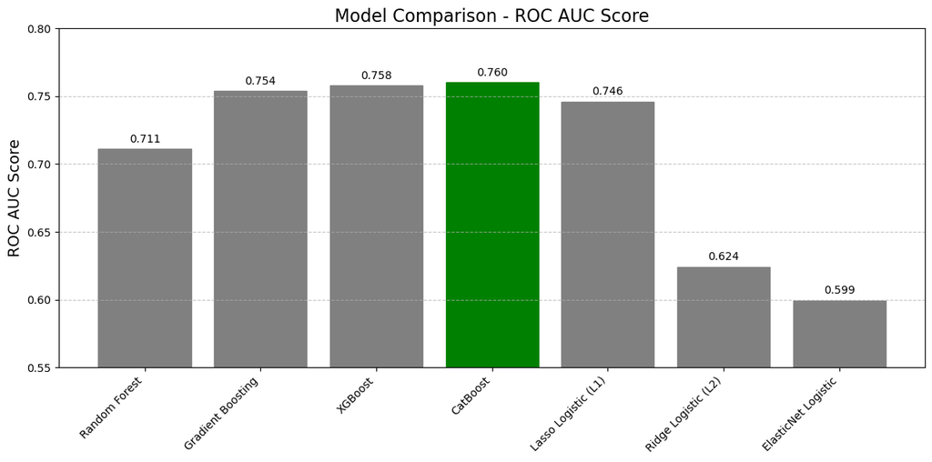

```python
import matplotlib.pyplot as plt
import numpy as np

# Models and their ROC AUC scores
models = [
    'Random Forest', 'Gradient Boosting', 'XGBoost', 'CatBoost',
    'Lasso Logistic (L1)', 'Ridge Logistic (L2)', 'ElasticNet Logistic'
]
roc_auc_scores = [
    0.7111, 0.7537, 0.7578, 0.7601,
    0.7460, 0.6242, 0.5992
]

# Bar chart
plt.figure(figsize=(12, 6))
bars = plt.bar(models, roc_auc_scores)

# Highlighting the best model (CatBoost)
for bar, score in zip(bars, roc_auc_scores):
    if score == max(roc_auc_scores):
        bar.set_color('green')
    elif 'Logistic' in bar.get_label():
        bar.set_color('skyblue')
    else:
        bar.set_color('gray')

# Titles and labels
plt.title('Model Comparison - ROC AUC Score', fontsize=16)
plt.ylabel('ROC AUC Score', fontsize=14)
plt.xticks(rotation=45, ha='right')
plt.ylim(0.55, 0.80)
plt.grid(axis='y', linestyle='--', alpha=0.7)

# Adding data labels
for i, v in enumerate(roc_auc_scores):
    plt.text(i, v + 0.005, f'{v:.3f}', ha='center', fontsize=10)

plt.tight_layout()
plt.show()
```

### Executive Summary Key Points

| Model Category | Best Model | ROC AUC |
| --- | --- | --- |
| Ensemble Models | CatBoost | 0.7601 |
| GLM Models | Lasso Logistic Regression (L1) | 0.7460 |

- Ensemble models outperform GLMs in this dataset.
- Among GLMs, **Lasso (L1)** offers the best balance between model simplicity and performance.

### Code Explanation

# Final Conclusion

In this assignment, we built and evaluated GLM models (Lasso, Ridge, ElasticNet) for predicting loan default risks on an imbalanced dataset.

- L1 Logistic Regression (Lasso) achieved the best recall (67.11%) and strong ROC AUC (~0.7460) among GLMs.
- L2 Logistic Regression (Ridge) showed moderate performance with ROC AUC ~0.6242.
- ElasticNet performed the weakest among the three GLMs (~0.5992 ROC AUC).

Each model was evaluated using Accuracy, Precision, Recall, F1 Score, ROC AUC, and Cumulative Lift charts. We also visualized the top 15 most important features influencing model predictions. Ensemble models from Assignment-1 (Random Forest, GBM, XGBoost, CatBoost) were compared.

- CatBoost achieved the highest ROC AUC (0.7601), making it the best overall model.
- Lasso Logistic Regression was the best among GLMs for simplicity and strong recall.

**Final Recommendations:**

- Use CatBoost for maximum predictive power.
- Use Lasso Logistic Regression for simple, interpretable, and high-recall scenarios.

**Additional Insights:**

Through this assignment, it became clear that while traditional GLM models can achieve good performance with appropriate regularization and handling of class imbalance, ensemble techniques like CatBoost consistently offer superior results for complex, high-stakes problems like credit risk prediction. Moreover, the careful evaluation using multiple performance metrics and the use of lift charts provided a deeper understanding of model behavior beyond mere accuracy. This structured and multi-faceted approach to model selection is essential for designing reliable, production-ready solutions in real-world financial risk environments.